# Módulo 3: Documento HTML

Regina Anaid Martínez Lobato

2026-02-01

## Actividades

### Estilo y apariencia de Documentos HTML

“There are several options that control the appearance of HTML documents:

`theme` specifies the Bootstrap theme to use for the page (themes are drawn from the Bootswatch theme library). Valid themes include: **default, bootstrap, cerulean, cosmo, darkly, flatly, journal, lumen, paper, readable, sandstone, simplex, spacelab, united, and yeti**. *(Pass null for no theme (in this case you can use the css parameter to add your own styles))*.

`highlight` specifies the syntax highlighting style. Supported styles include `default`, `tango`, `pygments`, `kate`, `monochrome`, `espresso`, `zenburn`, `haddock`, `breezedark`, and `textmate`. *Pass null to prevent syntax highlighting*.

`smart` indicates whether to produce typographically correct output, converting straight quotes to curly quotes, `---` to em-dashes, `--` to en-dashes, and `...` to ellipses. Note that `smart` is enabled by default [^1].”

> “Otra forma de cambiar el aspecto y estilo del documento HTML es usando **cascading style sheets** *((hojas de estilo en cascada))*, o `CSS`”

### Crear un archivo CSS

Para crear un archivo CSS, ir a `File` $\rightarrow$ `New File` $\rightarrow$ `Text File`

> “Es un archivo simple con comandos de texto”

Se estarán creando **definiciones CSS**:

- Se copia el texto indicado en la lección

```
#nextsteps{
  color: blue
}

.emphasized{
  font-size: 1.2em
}
```

La opción `emphasized` hace el tamaño de la fuente más grande, en éste caso la hace $1.2$ veces más grande que la fuente estándar.

Se guarda el archivo dando un nombre, seguido de `.css`, en este caso `micss.css`.

Regresando al archivo `Rmd`, se cambian las opciones de la cabecera YAML quitando `theme` y `hightlight`, y se agrega la opción para el `CSS`:

```
css: micss.css
"recordando que se dejan 2 espacios"
```

Se aplican a las propiedades al encabezado agregando llaves seguido de las opciones creadas en el CSS: `### Estilo y apariencia de Documentos HTML {#nextsteps .emphisized}` y se observa que toda la sección cambia de color y tamaño de letra.

### Definir tamaño de figuras para todo el documento HTML

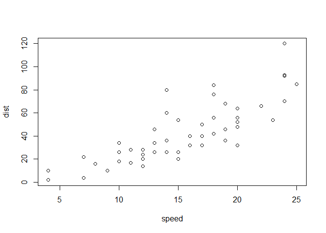

```r
plot(cars)
```

Las medidas estándar de las figuras son 7 de ancho y 5 de alto, medidas están indicadas en pulgadas.

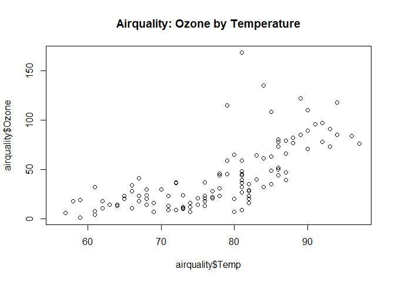

```r
plot(airquality$Temp, airquality$Ozone,
        main="Airquality: Ozone by Temperature")
```

También se puede acceder a éstas opciones directamente dentro de `Output Options...` a la derecha del engrane de `Knit`.

## Añadir Índice

- Se agregan dos secciones más para verlas listadas en el índice.
- Se puede agregar directamente en el encabezado YAML agregando la palabra clave `toc`, o en `Output Options...` dando click a la casilla de `Include table of contents`.
- El encabezado se actualiza de forma automática agregando `toc: true` *(nótese que en el curso la salida es `toc: yes`)*
- Para que el índice aparezca flotando a la izquierda, se agrega en YAML: `toc_float: true`

## Summary of Air Quality Dataset

- **Ozone**: *(Mean ozone in parts per billion (ppb) from 1300 to 1500 hours at Roosevelt Island)*
- **Solar.R**: *(Solar radiation in Langleys (lang) in the frequency band 4000–7700 Angstroms from 0800 to 1200 hours at Central Park)*
- **Wind**: *(Average wind speed in miles per hour (mph) at 0700 and 1000 hours at LaGuardia Airport)*
- **Temp**: *(Maximum daily temperature in degrees Fahrenheit (oF) at LaGuardia Airport)*
- **Month**: *(numeric month (1-12))*
- **Day**: *(numeric Day of the month (1-31))*

### Table of Top of the Air Quality Dataset

```r
knitr::kable(head(airquality),
                      caption = "Top of the Air Quality Dataset")
```

Top of the Air Quality Dataset

| Ozone | Solar.R | Wind | Temp | Month | Day |
| --- | --- | --- | --- | --- | --- |
| 41 | 190 | 7.4 | 67 | 5 | 1 |
| 36 | 118 | 8.0 | 72 | 5 | 2 |
| 12 | 149 | 12.6 | 74 | 5 | 3 |
| 18 | 313 | 11.5 | 62 | 5 | 4 |
| NA | NA | 14.3 | 56 | 5 | 5 |
| 28 | NA | 14.9 | 66 | 5 | 6 |

### Plot of Ozone by Temperature –Air Quality Dataset

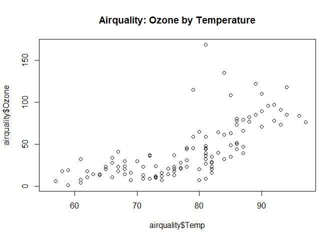

```r
plot(airquality$Temp, airquality$Ozone,
        main="Airquality: Ozone by Temperature")
```

## Plegado de código

Opción para ocultar o mostrar código en el documento, a menos que el lector de click al botón resultante para mostrar el código. En la parte superior de la página, aparece un botón `Code`, que indica si se desea **Show All Code** o **Hide All Code**.

**NOTA**: Si dentro de la sección de código aparece `echo=FALSE`, la sección de código nunca se mostrará, aunque se utilice la opción de plegado de código.

### Mantener un documento Markdown

Mantener un documento R Markdown se agrega en la cabecera YAML `keep_md: true`

En los documentos obtenidos al compilar, además del llamado *html_document.Rmd* y *el html_document.html*, se obtiene uno llamado **html_document.md**. *“GitHub fue construído de forma nativa para mostrar documentos Markdown”*

### Guardar el documento actual HTML en otro nombre de archivo

Dar click en `File` $\rightarrow$ `Save As..` $\rightarrow$ Cambiar nombre del documento a `githubmd_document.Rmd` *(Se está creando un documento GitHub Markdown)* $\rightarrow$ `Guardar`.

Se regresa a la cabecera YAML: En vez de un documento HTML se va a utilizar un documento md, para un documento markdown y específicamente crear una variante de GitHub.

```
  md_document:
    variant: markdown_github
```

- Crear una carpeta `docs` dentro de la carpeta de proyecto del Módulo 3 (crear directamente en el directorio).
- Crear una copia del documento HTML y agregarla dentro de la carpeta *(se agregó también copia de la carpeta de HTML)*.

### Crear un Índice

Tomar el documento HTML que quedó en la raíz de la carpeta, y guardar con un nombre distinto.

Dar click en `File` $\rightarrow$ `Save As..` $\rightarrow$ Cambiar nombre del documento a `index.Rmd` $\rightarrow$ `Guardar`.

Compilar a HTML.

Se hace una copia y se pega en la carpeta de `docs`.

Compilar y sincronizar cambios con repositorio de GitHub

[^1]: Texto tomado de: https://bookdown.org/yihui/rmarkdown/html-document.html#appearance-and-style
[^2]: Chambers, J. M., Cleveland, W. S., Kleiner, B. and Tukey, P. A. (1983) Graphical Methods for Data Analysis. Belmont, CA: Wadsworth.